# Happiness Index: A Closer Look

## Happiness World Report

This project examines datasets from different years that measure variables that have an influence on the “Happiness Index” score for different countries. It explores relationships between variables and determines which are most influential.

**Data:** Comes from Kaggle: https://www.kaggle.com/mathurinache/world-happiness-report?select=2020.csv https://www.kaggle.com/ajaypalsinghlo/world-happiness-report-2021

The datasets of 2020 and 2021 include both the actual values for each variable (explained below) and also the extent to which each variable contributed to the calculation of the happiness score.

**Ladder score**: a national average of the responses to the main life evaluation question asked in the Gallup World Poll (GWP), which uses the Cantril Ladder - A method of ranking one’s happiness in a scale of 1 to 10.

**GDP per capita**: The Logged Gross Domestic Product Divided by population

**Healthy life expectancy**: The average healthy life expectancy of the general population, based on the data extracted from the World Health Organization’s (WHO) Global Health Observatory data repository

**Freedom to make life choices**: The score of the individual freedoms in that country or region ○ the national average of binary responses (1= satisfied, 2=satisfied) to the GWP question “Are you satisfied or dissatisfied with your freedom to choose what you do with your life?”

**Generosity**: the residual of regressing national average in response to the GWP question “Have you donated money to a charity in the past month?” on GDP per capita.

**Perceptions of corruption**: The degree to which the public views their government as corrupt. The national average of the survey responses to two questions: “Is corruption widespread throughout the government or not” and “Is corruption widespread within businesses or not?” The overall perception is just the average of the two 0-or-1 responses.

**Read in 2020 data, Exploratory Analysis**

```r
data2020 <- read_csv("data/2020.csv")
head(data2020)
```

```
## # A tibble: 6 x 20
##   `Country name` `Regional indica~ `Ladder score` `Standard error ~ upperwhisker
##   <chr>          <chr>                      <dbl>             <dbl>        <dbl>
## 1 Finland        Western Europe              7.81            0.0312         7.87
## 2 Denmark        Western Europe              7.65            0.0335         7.71
## 3 Switzerland    Western Europe              7.56            0.0350         7.63
## 4 Iceland        Western Europe              7.50            0.0596         7.62
## 5 Norway         Western Europe              7.49            0.0348         7.56
## 6 Netherlands    Western Europe              7.45            0.0278         7.50
## # ... with 15 more variables: lowerwhisker <dbl>, Logged GDP per capita <dbl>,
## #   Social support <dbl>, Healthy life expectancy <dbl>,
## #   Freedom to make life choices <dbl>, Generosity <dbl>,
## #   Perceptions of corruption <dbl>, Ladder score in Dystopia <dbl>,
## #   Explained by: Log GDP per capita <dbl>, Explained by: Social support <dbl>,
## #   Explained by: Healthy life expectancy <dbl>,
## #   Explained by: Freedom to make life choices <dbl>, ...
```

**Rename the Variables**

```r
d2020 <- data2020 %>%
  rename(ladder = "Ladder score",
         country = "Country name",
         life_expectancy = "Explained by: Healthy life expectancy",
         freedom_choices = "Explained by: Freedom to make life choices",
         generosity = "Explained by: Generosity",
         corruption_perception = "Explained by: Perceptions of corruption",
         GDP = "Explained by: Log GDP per capita",
         social_support = "Explained by: Social support") %>%
  select(country, ladder, GDP, social_support, life_expectancy, freedom_choices, generosity, corruption_perception)
head(data2020)
```

```
## # A tibble: 6 x 20
##   `Country name` `Regional indica~ `Ladder score` `Standard error ~ upperwhisker
##   <chr>          <chr>                      <dbl>             <dbl>        <dbl>
## 1 Finland        Western Europe              7.81            0.0312         7.87
## 2 Denmark        Western Europe              7.65            0.0335         7.71
## 3 Switzerland    Western Europe              7.56            0.0350         7.63
## 4 Iceland        Western Europe              7.50            0.0596         7.62
## 5 Norway         Western Europe              7.49            0.0348         7.56
## 6 Netherlands    Western Europe              7.45            0.0278         7.50
## # ... with 15 more variables: lowerwhisker <dbl>, Logged GDP per capita <dbl>,
## #   Social support <dbl>, Healthy life expectancy <dbl>,
## #   Freedom to make life choices <dbl>, Generosity <dbl>,
## #   Perceptions of corruption <dbl>, Ladder score in Dystopia <dbl>,
## #   Explained by: Log GDP per capita <dbl>, Explained by: Social support <dbl>,
## #   Explained by: Healthy life expectancy <dbl>,
## #   Explained by: Freedom to make life choices <dbl>, ...
```

```r
data2020 <- data2020 %>%
  rename(ladder = "Ladder score",
         country = "Country name",
         life_expectancy = "Healthy life expectancy",
         freedom_choices = "Freedom to make life choices",
         generosity = "Generosity",
         corruption_perception = "Perceptions of corruption",
         GDP = "Logged GDP per capita",
         social_support = "Social support") %>%
  select(country, ladder, GDP, social_support, life_expectancy, freedom_choices, generosity, corruption_perception)
```

**Pairs Plot To Look at the Relationships Between the variables**

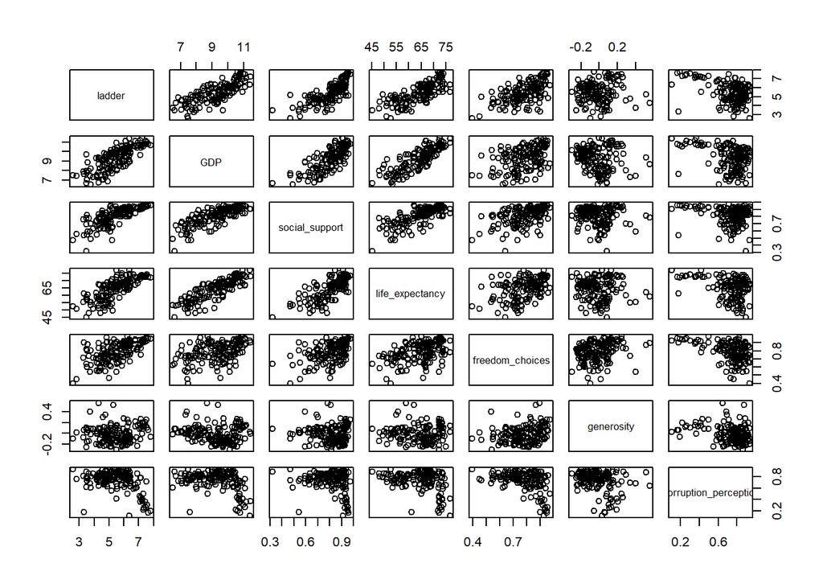

```r
data2020 <- data2020 %>%
  select(-country)
pairs(data2020[,1:7])
```

This pairs plot shows the relationship and correlations between the different variables. We can see strong correlations between ladder score and other variables, such as GDP, social_support, and life_expectancy. As these three variables increase, the ladder score increases as well.

**Plot to see relationships closer**

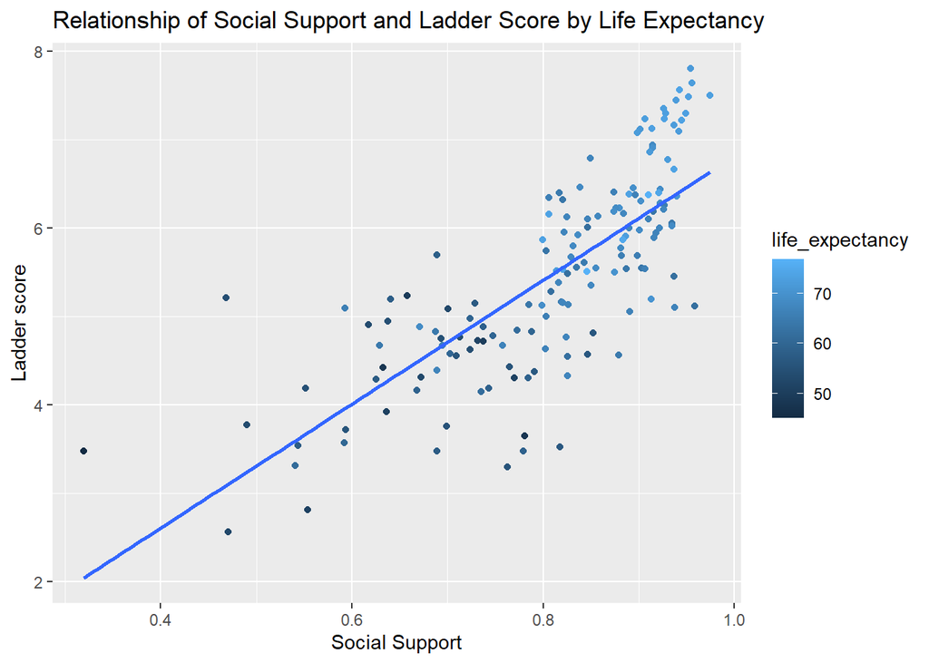

```r
ggplot(data2020, aes(x = social_support, y = ladder, color = life_expectancy)) +
    geom_point() +
    geom_smooth(method = "lm", se = FALSE) +
    ggtitle("Relationship of Social Support and Ladder Score by Life Expectancy") +
    xlab("Social Support") +
    ylab("Ladder score")
```

This graph takes a closer look at the relationship between social support (0-1.5) and ladder score(a country’s overall ranking of happiness defined by a public survey question response ranging from 0-10). The points are colored by life_expectancy, and we can see how life expectancy increases with the trend. The more social support, the higher the life expectancy, and the higher the ladder score.

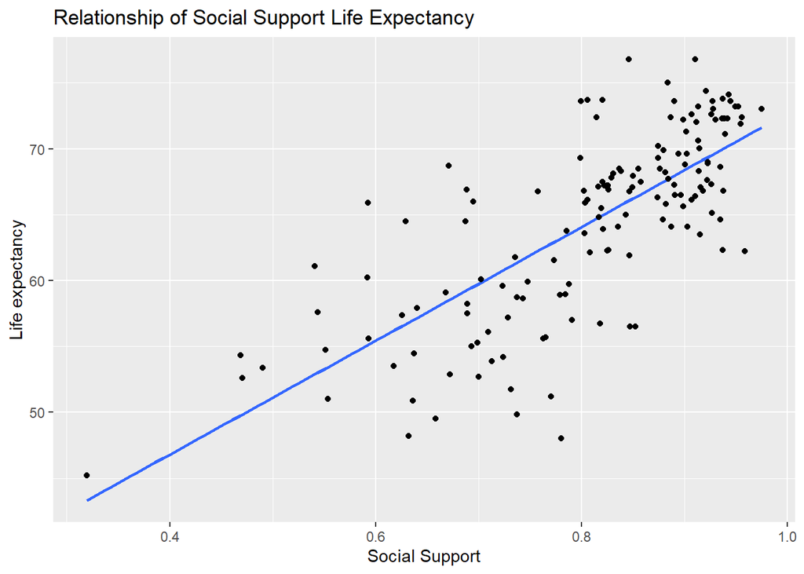

```r
ggplot(data2020, aes(x = social_support, y = life_expectancy)) +
    geom_smooth(method = "lm", se = FALSE) +
    geom_point() +
    ggtitle("Relationship of Social Support Life Expectancy") +
    xlab("Social Support") +
    ylab("Life expectancy")
```

The relationship between social support and life expectancy is also very clear, as social support increases so does life expectancy.

** Linear Regression on ladders score explained by social support **

```r
lm_social_support = lm(ladder~social_support, data = data2020)
summary(lm_social_support)
```

```
##
## Call:
## lm(formula = ladder ~ social_support, data = data2020)
##
## Residuals:
##      Min       1Q   Median       3Q      Max
## -2.01071 -0.38261 -0.04146  0.46455  2.12511
##
## Coefficients:
##                Estimate Std. Error t value Pr(>|t|)
## (Intercept)     -0.1926     0.3925  -0.491    0.624
## social_support   7.0059     0.4800  14.596   <2e-16 ***
## ---
## Signif. codes:  0 '***' 0.001 '**' 0.01 '*' 0.05 '.' 0.1 ' ' 1
##
## Residual standard error: 0.7187 on 151 degrees of freedom
## Multiple R-squared:  0.5852, Adjusted R-squared:  0.5825
## F-statistic: 213.1 on 1 and 151 DF,  p-value: < 2.2e-16
```

Taking a closer look at the plot, the relationship between ladder score and social support might not be linear. Here, we look at a linear, squared, and cubed relationship plus an intercept term:

First, divide the data into testing and training subsets to evaluate the fits:

```r
data2020 <- data2020 %>%
  mutate(testSet = 0)
n = nrow(data2020)
# randomly select 1/4 of the data to the test set
data2020[sample(1:nrow(data2020), size = nrow(data2020) / 4, replace = FALSE),]$testSet = 1
train = data2020 %>% filter(testSet == 0)
test = data2020 %>% filter(testSet == 1)
```

Training the three models with the training data:

```r
model1 <- lm(ladder ~ 1  + social_support, data =train)
model2 <- lm(ladder ~ 1 + I(social_support^2) , data =train)
model3 <- lm(ladder ~ 1 + I(social_support^3), data =train)
c( sum( model1$residuals^2 ), sum( model2$residuals^2 ), sum( model3$residuals^2 ) )
```

```
## [1] 59.72463 53.98780 51.01285
```

Using the regression models to predict the testing data, then calculating the sum of squared residuals (to measure error):

```r
probs1 <- predict(model1, type='response', newdata =  test)
probs2 <- predict(model2, type='response', newdata =  test)
probs3 <- predict(model3, type='response', newdata =  test)

# calculating the residual sums
test <- test %>%
  mutate(predictions1 = probs1,
         diff1 = ladder - predictions1,
         RSS_sum1 = diff1^2,
    predictions2 = probs2,
         diff2 = ladder - predictions2,
         RSS_sum2 = diff2^2,
    predictions3 = probs3,
         diff3 = ladder - predictions3,
         RSS_sum3 = diff3^2)

test %>%
  summarise(RSS1 = sum(RSS_sum1),
            RSS2 = sum(RSS_sum2),
            RSS3 = sum(RSS_sum3))
```

```
## # A tibble: 1 x 3
##    RSS1  RSS2  RSS3
##   <dbl> <dbl> <dbl>
## 1  22.3  20.7  19.9
```

Graphing the three model fits:

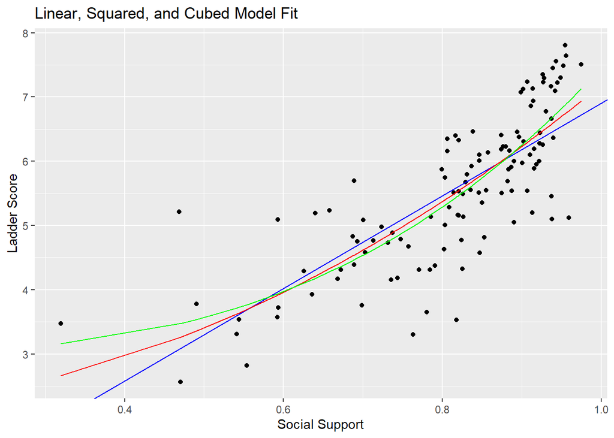

```r
intercept1 <- model1$coefficients[1]
slope1 <- model1$coefficients[2]

intercept2 <- model2$coefficients[1]
slope2 <- model2$coefficients[2]

intercept3 <- model3$coefficients[1]
slope3 <- model3$coefficients[2]

colors <- c("Linear" = "blue", "Squared" = "red", "Cubed" = "green")

pp <- ggplot( data2020, aes(x=social_support, y=ladder)) + geom_point()
pp <- pp + geom_abline(intercept=intercept1, slope=slope1, colour='blue' )
pp <- pp + geom_line(aes(x=social_support, y=intercept2 + slope2*I(social_support^2)), colour='red' )
pp <- pp + geom_line( aes(x=social_support, y=intercept3 + slope3*I(social_support^3)), colour='green' )
pp <- pp + xlab("Social Support") + ylab("Ladder Score") + ggtitle("Linear, Squared, and Cubed Model Fit") + labs(color = "Legend")
pp <- pp + labs(color = "Legend" +   scale_color_manual(values = colors))
pp
```

The cubed fit is the green line, and it is the one that decreases the sum of the residuals and therefore better predicts the ladder score.

**Reading in the 2021 data and renaming the variables**

```r
data2021 <- read_csv("data/2021.csv")
data2021 <- data2021 %>%
  rename(ladder = "Ladder score",
         country = "Country name",
         life_expectancy = "Healthy life expectancy",
         freedom_choices = "Freedom to make life choices",
         generosity = "Generosity",
         corruption_perception = "Perceptions of corruption",
         GDP = "Logged GDP per capita",
         social_support = "Social support") %>%
  select(country, ladder, GDP, social_support, life_expectancy, freedom_choices, generosity, corruption_perception)

head(data2021)
```

```
## # A tibble: 6 x 8
##   country     ladder   GDP social_support life_expectancy freedom_choices generosity
##   <chr>        <dbl> <dbl>          <dbl>           <dbl>           <dbl>      <dbl>
## 1 Finland       7.84  10.8          0.954            72             0.949     -0.098
## 2 Denmark       7.62  10.9          0.954            72.7           0.946      0.03
## 3 Switzerland   7.57  11.1          0.942            74.4           0.919      0.025
## 4 Iceland       7.55  10.9          0.983            73             0.955      0.16
## 5 Netherlands   7.46  10.9          0.942            72.4           0.913      0.175
## 6 Norway        7.39  11.1          0.954            73.3           0.96       0.093
## # ... with 1 more variable: corruption_perception <dbl>
```

We are going to use the 2020 data to estimate the 2021 data, using all of the variables. First, for a santiy check we divide the 2020 data into training and testing sets, to check the linear model as well as the residual sum of squares on the testing set.

```r
data2020 <- data2020 %>%
    mutate(year = 2020,
         testSet = 0) %>%
  select(ladder, GDP, social_support, life_expectancy, freedom_choices, generosity, corruption_perception, year, testSet)

data2020[sample(1:nrow(data2020), size = nrow(data2020) / 4, replace = FALSE),]$testSet = 1

fullData = data2020
testSet = fullData %>% filter(testSet == 1)
trainSet = fullData %>% filter(testSet == 0)
```

Run a regression with all of the variables on the train dataset, and use this regression to predict the values of the testing dataset. The error is compared and measured by summing the squared residuals. The social support term is cubed, as this seemed to be the best ladder score predictor for this variable.

```r
lm2020 = lm(ladder ~ 1 + GDP + I(social_support^3) + life_expectancy + freedom_choices + generosity + corruption_perception, data = trainSet)
sum(lm2020$residuals^2 )
```

```
## [1] 32.58616
```

```r
summary(lm2020)
```

```
##
## Call:
## lm(formula = ladder ~ 1 + GDP + I(social_support^3) + life_expectancy +
##     freedom_choices + generosity + corruption_perception, data = trainSet)
##
## Residuals:
##     Min      1Q  Median      3Q     Max
## -1.4799 -0.2844  0.0352  0.3259  1.3937
##
## Coefficients:
##                       Estimate Std. Error t value Pr(>|t|)
## (Intercept)           -1.55908    0.93428  -1.669  0.09806 .
## GDP                    0.25846    0.10337   2.500  0.01391 *
## I(social_support^3)    1.60491    0.45130   3.556  0.00056 ***
## life_expectancy        0.03564    0.01449   2.460  0.01548 *
## freedom_choices        2.29102    0.52625   4.353 3.06e-05 ***
## generosity            -0.21187    0.38994  -0.543  0.58802
## corruption_perception -0.52435    0.35784  -1.465  0.14574
## ---
## Signif. codes:  0 '***' 0.001 '**' 0.01 '*' 0.05 '.' 0.1 ' ' 1
##
## Residual standard error: 0.5493 on 108 degrees of freedom
## Multiple R-squared:  0.7963, Adjusted R-squared:  0.785
## F-statistic: 70.38 on 6 and 108 DF,  p-value: < 2.2e-16
```

```r
probs <- predict(lm2020, type='response', newdata =  testSet)
testSet = testSet %>%
  mutate(predictions = probs,
         diff = ladder - predictions,
         RSS = diff^2)
#calculate RSS of train and compare to rss from test
# comparing different number of observations, divide by n?
testSet %>%
  summarise(RSS_sum = sum(RSS))
```

```
## # A tibble: 1 x 1
##   RSS_sum
##     <dbl>
## 1    12.1
```

Now we can train the model using all of the data from 2020 and use this model to predict the ladder scores of 2021. We can then measure accuracy using the residual sum of squares.

Predict 2021 using 2020 regression:

```r
lm_full = lm(ladder ~ 1 + GDP + I(social_support^3) + life_expectancy + freedom_choices + generosity + corruption_perception, data = data2020)
sum(lm_full$residuals^2 )
```

```
## [1] 44.43763
```

Comparing the residuals from the 2020 model to its predictions on the 2021 data.

```r
probs <- predict(lm_full, type='response', newdata =  data2021)
data2021 = data2021 %>%
  mutate(predictions = probs,
         diff = ladder - predictions,
         RSS = diff^2)
#calculate RSS of 2021 and compare to rss from 2020
data2021 %>%
  summarise(RSS_sum = sum(RSS))
```

```
## # A tibble: 1 x 1
##   RSS_sum
##     <dbl>
## 1    42.6
```

```r
summary(lm_full)
```

```
##
## Call:
## lm(formula = ladder ~ 1 + GDP + I(social_support^3) + life_expectancy +
##     freedom_choices + generosity + corruption_perception, data = data2020)
##
## Residuals:
##      Min       1Q   Median       3Q      Max
## -1.63388 -0.29475  0.04693  0.34070  1.36001
##
## Coefficients:
##                       Estimate Std. Error t value Pr(>|t|)
## (Intercept)           -1.50825    0.82107  -1.837 0.068253 .
## GDP                    0.22690    0.09003   2.520 0.012801 *
## I(social_support^3)    1.45856    0.38680   3.771 0.000236 ***
## life_expectancy        0.04372    0.01320   3.311 0.001172 **
## freedom_choices        2.18484    0.47167   4.632 7.94e-06 ***
## generosity            -0.24246    0.31424  -0.772 0.441621
## corruption_perception -0.68704    0.30753  -2.234 0.027001 *
## ---
## Signif. codes:  0 '***' 0.001 '**' 0.01 '*' 0.05 '.' 0.1 ' ' 1
##
## Residual standard error: 0.5517 on 146 degrees of freedom
## Multiple R-squared:  0.7852, Adjusted R-squared:  0.7764
## F-statistic: 88.96 on 6 and 146 DF,  p-value: < 2.2e-16
```

**Discussion**

This project explored the impact that different variables have on the happiness ladder score. We used the data from 2020 to come up with a model, and then used this model to predict the data from 2021. The variables were associated with happiness ladder score were social support cubed, life expectancy, freedom to make choices, and perception of corruption.

The model was evaluated using the sum of residuals squared, and a different method for checking the accuracy of the model might lead to a different conclusion. Also, this project only looked at associations and how the variables how the their are correlated, casual claims cannot be made. More research is needed.